# Virginia Math Bulletin 2019 — UVA Mathematics

Virginia Math Bulletin

Faculty News

Department of Mathematics Activities

University of Virginia

# View from the Chair

**John Imbrie**  
**Professor of Mathematics/Chair** The last year was an eventful one for mathematics at UVa. We had a big year in terms of new tenured/tenure-track faculty. Two new assistant professors, Evangelia Gazaki and You Qi, joined our ranks, and we were also very fortunate to be able to recruit Ken Ono as the Thomas Jefferson Professor of Mathematics. Evangelos Dimou is joining our general faculty team that is focused on renewing our calculus program. Read ahead for profiles of all of our new faculty, as well as our new postdocs Bruno Braga, Anna Pun, and Charlotte Ure. It is particularly meaningful for me as chair to see the new faculty begin to shape the department and to assume their role as mentors for the next generation of mathematicians.

This year, we are gearing up for a major expansion of our postdoc program. One component of this relates to our ambitious plans to extend our smaller-class, interactive model for calculus to our applied calculus sequence. Smaller class sizes means more instructors, and additional postdocs will help with that. The other component relates to a large five-year NSF award to our topology-geometry group, which includes the hiring of two new postdocs each year for three years. Read ahead for an article on the new RTG grant (Research Training Grant).

Other highlights of this edition of the Virginia Math Bulletin include an article by Weiqiang Wang on his recent landmark work on Lie theory with his former student, Huanchen Bao, articles on undergraduate research projects conducted in the last year, and articles on activities of our AWM chapter (American Women in Mathematics). You can read about our Virginia Math Lectures by Fields medalist

[figure not shown]

Andrei Okounkov and Pólya Prize winner Van Vu. There is an article about the career of Nat Martin, one of our emeritus faculty, who passed away this past year. He joined the department in 1959 and was a fixture here for nearly 40 years.

We are just now finishing up an intensive period of renovations to Kerchof Hall, including a renewal of our lounge and kitchen area. The Math Lounge is a dream given form, giving a place for all of us to socialize, meet, and interact. I hope that whenever you are in town, you will take the time to visit and see for yourself by joining us for one of our Tuesday/ Thursday teas. Or should I say coffees? We are testing Rényi’s claim that a mathematician is a device for turning coffee into theorems.

I am particularly grateful for the support of the larger community of graduates and former members of this department. We are looking forward to another exciting year in the department, with new discoveries, involving our very talented graduate and undergraduate students, postdoctoral fellows, and faculty. Please enjoy this newsletter and let us know what you think. We hope you will stay in touch and I welcome your comments and questions.

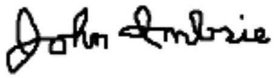

## Supporting Us

The Mathematics Department is grateful for the generous support of its alumni and friends. The Department welcomes gifts annually to address its most urgent needs, as well as to the endowment which provides funding in perpetuity. To learn about how you can make a difference by supporting the Mathematics Department, please contact Liz Blaine at lblaine@virginia.edu or (434) 924-6156. To make a gift online, please visit http://giving.virginia.edu/mathematics

## New Faculty Profiles

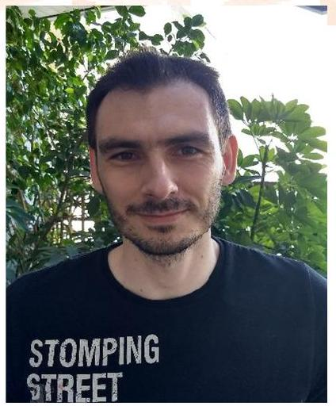

### Evangelos Dimou, Assistant Professor/General Faculty

(2019- )  
Evangelos Dimou’s research interests lie within the study of harmonic analysis, more specifically the study of Fourier restriction and related problems. Focused on the teaching of mathematics after completing his Ph.D., Dimou began exploring methods and practices of teaching that enhance student learning. He was recently admitted to the 2019 Silver cohort of Project NExT (New Experiences of Teaching), a professional development program for new or recent Ph.D.s in the mathematical sciences, sponsored by the Mathematical Association of America.

Dimou received his bachelor’s and master’s degrees from the University of Athens in Greece before moving to the United States, where he completed his Ph.D. at the University of Wisconsin-Madison in 2016. Before joining the University of Virginia, he held the position of Lecturer I at the University of Michigan.

This fall, Dimou will teach two sections of Calculus II, while assisting efforts by the Department of Mathematics to transform its calculus program into one based on active learning.

### Evangelia Gazaki, Assistant Professor (2019– )

A pure mathematician, Evangelia Gazaki focuses her research in the intersection of number theory and algebraic geometry, usually referred to as arithmetic geometry.

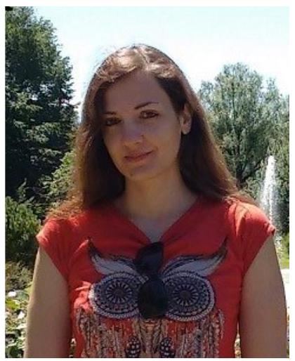

Her main interests include $K$-theory and its relations to algebraic cycles, and $p$-adic Hodge theory. She has published a number of research articles and has been awarded various teaching awards.

Her research has been partially supported by awards from the Simons Foundation as well as the National Science Foundation.

Before joining the University of Virginia, Gazaki earned her Ph.D. degree in mathematics from the University of Chicago (2016). She held a postdoctoral assistant professor position at the University of Michigan (2016-2019).

Gazaki is currently focusing her research on global-to-local principles for zero-cycles and on relations between Milnor $K$-theory and $p$-adic Hodge theory. Joining the Department of Mathematics, Gazaki will teach "Introduction to Real Analysis" this fall and "Graduate Algebra II" in the spring semester. She is also looking forward to get involved with undergraduate activities, including the Directed Reading Program and the Undergraduate Math Club.

### Ken Ono, Thomas Jefferson Professor of Mathematics

(2019- )  
An internationally recognized expert in the theory of modular forms, Ken Ono edits multiple journals and serves as vice president of the American Mathematical Society. He has published more than 180 research and popular

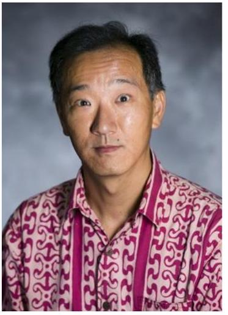

articles and several monographs on number theory, combinatorics and algebra. Ono’s recent work includes a paper he recently coauthored on the Riemann Hypothesis - an unsolved but influential 160-year-old conjecture related to prime numbers - that prompted widespread coverage in the scientific press.

Ono earned his Ph.D. in 1993 from UCLA and joined the University of Virginia from Emory University. He has received many awards for his research, including a Guggenheim Fellowship, a Packard Fellowship and a Sloan Research Fellowship. He was awarded a Presidential Early Career Award for Science and Engineering (PECASE) by former President Bill Clinton in 2000 and was named a Distinguished Teaching Scholar by the National Science Foundation in 2005. He is a member of the U.S. National Committee for Mathematics at the National Academy of Sciences.

He was also an associate producer of the Hollywood film, The Man Who Knew Infinity, about Srinivasa Ramanujan, the Indian mathematician who died at age 32 in 1920. Although he never finished college, Ramanujan left behind a collection of notebooks filled with strikingly original formulas that continue to yield important applications today. Ono now directs the Spirit of Ramanujan STEM talent search (spiritoframanujan.com) to identify and support "the next Ramanujans" around the world.

### You Qi, Assistant Professor (2019– )

With a keen interest in understanding symmetries in mathematics and quantum physics, You Qi

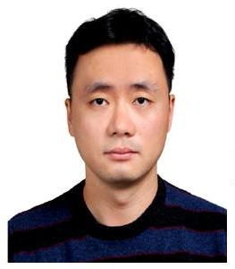

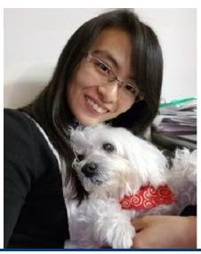

researches higher representation theory and algebraic geometry, and their applications to low dimensional topology. Currently, he is working on the categorification of small quantum groups - a special class of finite dimensional Hopf algebras - while aiming to construct four-dimensional topological quantum field theories out of them. He is also investigating the algebro-geometric meaning behind the small quantum groups.

Since 2017, Qi’s work has been partially supported by the National Science Foundation. His published works include journal and book series articles in American Mathematical Society Contemporary Mathematics, International Mathematics Research Notices, Journal of the Institute of Mathematics of Jussieu, and Proceedings of the London Mathematical Society.

Originally from Chengdu, China, Qi received his B.S. degree from Tsinghua University in Beijing, and an M.S. degree from Hong Kong University of Science and Technology.

In 2013, he obtained his Ph.D. in mathematics from Columbia University.

Since then, he has held postdoctoral positions at the University of California, Berkeley, and Yale University. Before joining UVA, he was the Sherman-Fairchild Research Assistant Professor at the California Institute of Technology.

In his first academic year at UVA, Qi plans to teach courses on linear algebra and advanced calculus, while organizing departmental research seminars in algebra and representation theory. He also will work with students preparing for the William Lowell Putnam Mathematical competition, the preeminent mathematics competition for undergraduate students in the United States and Canada.

### Bruno Braga, Mary Ann Pitts Research Associate (2019– )

Braga’s research interests lie in the broad realm of functional analysis. More

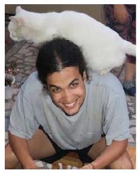

specifically, his main interest is in large scale geometry in functional analysis. During his Ph.D., Braga has written papers on descriptive set theory of separable Banach spaces and on the nonlinear geometry of Banach spaces. Following his Ph.D., Braga joined York University, Toronto, Canada, as a York Science Fellow, funded by the Simons Foundation. At York, Braga started his research on operator algebras, and he is currently working on rigidity questions for uniform Roe algebras and the nonlinear geometry of operator spaces.

Braga received both his B.S. in mathematics (2009) and his M.S. in mathematics (2010) from the Federal University of Rio de Janeiro (UFRJ), Rio de Janeiro, Brazil. Braga earned a Ph.D. in Mathematics from both Kent State University and the University of Illinois at Chicago (2017).

Braga is teaching a section of Calculus III this fall and he will be teaching two sections of Differential Equations in the spring.

### Anna Pun, Whyburn Research Associate (2019– )

Anna Pun is working in Algebraic

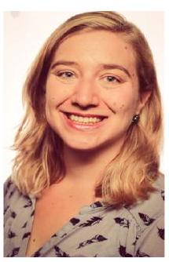

combinatorics, a subject that interprets algebraic objects combinatorially. Her joint research project focusing on different families of symmetric functions resolved several decades old positivity conjectures and was recently published in the Journal of the American Mathematical Society. She also has research experience in non-symmetric functions, finite geometry and block design theory with a publication in Designs, Codes and Cryptography. She loves to explore different areas in mathematics and is always excited to learn new topics.

Anna completed her Bachelor of Science degree (2009) and MPhil degree (2011) at the University of Hong Kong. After receiving her PhD in mathematics from the University of Pennsylvania (2016) under the supervision of Prof. Jim Haglund, she served as a visiting assistant professor at Drexel University (2016-2019). She just joined the University of Virginia this year. She received a postdoctoral fellowship at Institut Mittag-Leffler and will attend a combinatorics workshop in Sweden for the spring semester of 2020.

Anna has been teaching different levels of mathematics, from elementary school to college level courses, including different levels of calculus (and pre-calculus), linear algebra, and discrete mathematics. She loves teaching because she can share what she likes with others and learns a lot in doing so.

At UVA, she will continue her research in algebraic combinatorics, explore connections in different research areas, and share mathematics with students in a way that they would enjoy the subject and see the beauty in it.

### Charlotte Ure, Research Associate (2019– )

Working at the intersection of algebraic geometry, noncommutative algebra, and number theory, Charlotte Ure is interested in questions related to cohomology and rationality. Specifically, she studies the Brauer group of elliptic curves, and generalized Clifford algebras in higher degree. Her current research also involves the unramified cohomology of curves.

After receiving her Bachelor’s degree from the University of Heidelberg, Charlotte completed her Ph.D. at Michigan State University this year.

Charlotte has taught various mathematics courses throughout her academic career, including trigonometry, calculus, and introduction to proofs. Additionally, Charlotte has volunteered with the Deutsche SchülerAkademie, which is a summer program for gifted high school students in Germany.

At UVa, she will primarily work with our faculty who specialize in algebra. In her free time, Charlotte plans to explore the hiking trails around Charlottesville.

## Math Department Awarded a $2.5 Million Research Training Group Grant

By Thomas Mark

The Topology and Geometry group in the Department of Mathematics is happy to announce that they are the recipient of a five year $2.5 million Research Training Group grant from the National Science Foundation.

The NSF RTG program is aimed at strengthening the nation’s scientific competitiveness by increasing the number of well-prepared U.S. residents who pursue careers in the mathematical sciences. Nationally, roughly 5 RTG grants are awarded each year by the NSF to support efforts to improve research training by involving undergraduate students, graduate students, postdoctoral associates, and faculty members in structured research groups centered on a common research theme.

### About Topology

Geometric Topology and Algebraic Topology are areas of mathematics in which one is trying to understand aspects of the global shape of objects, with tools for doing this coming from various mathematical disciplines. Most classically, the objects of study are curves, surfaces, and higher dimensional analogues of these - manifolds, but modern topology also studies things like the ’shape’ of algebraic structures like number systems satisfying an associative law. Symmetries, in the guise of group theory, also play a major role. Applications range from the use of curvature and symmetry in mathematical physics to the use of homology theory in the emerging field of topological data analysis.

### The UVA Topology Group

The University of Virginia has a long and strong legacy of research in topology. The current UVA topology faculty, who will be leading the RTG activities, are as follows.

Julia Bergner (Professor) studies algebraic and higher categorical structures informed by the homotopical methods of algebraic topology.

Thomas Koberda (Associate Professor) studies geometric group theory, particularly groups arising as symmetries on curves and surfaces.

Slava Krushkal (Professor) works in low-dimensional and geometric topology, with interests including $3$ and $4$ dimensional manifolds and quantum topology.

Nicholas Kuhn (Professor) is an algebraic topologist who studies the interplay between stable, unstable, and chromatic homotopy.

Sara Maloni (Assistant Professor) has interests lying at the intersection of geometry and low-dimensional topology, studying deformations of geometric structures.

Thomas Mark (Professor) studies the differential and symplectic topology of $3$- and $4$-dimensional manifolds, and developing tools for their study.

### Grant Activities

Many of the activities to be funded by the grant will be enhanced version of programs already being piloted at UVA.

The grant will fund six 3-year postdoctoral positions, roughly doubling the number of these researchers in our department. For these new PhDs, the grant will provide:

- Enhanced research opportunities, to work with UVA topology faculty, fellow postdocs, graduate students, and participate in our regional collaborative research initiative.
- Mentoring opportunities, to work both with graduate students, and undergraduates through our summer REU program.

For graduate students, the grant will provide:

- Graduate traineeships, enhanced graduate fellowships, providing additional time to devote to research and participation in our seminar-style courses.
- Pre-graduate summer training, an intensive course for incoming graduate students aimed particularly at those from diverse undergraduate programs where few pursue graduate studies.
- Mentoring opportunities to work with undergraduates in our summer program.
- Research opportunities to work with our new PhD postdoctoral faculty, and be involved in the grant’s regional collaboration initiative and conferences.

For undergraduate students, the grant will provide:

- A Research Experiences for Undergraduates summer program, building on the department’s collective experience with undergraduate research.
- A directed reading program, an opportunity for individual or small groups to pursue academic year directed reading projects.

The grant also provides resources for regional outreach:

- A regional collaborative research initiative including faculty, postdocs, and graduate students from UVA and regional colleges and universities.
- Conferences, seminars, and public lectures, building on the mid-Atlantic Topology Conference series, as well as the broadly-accessible Virginia Mathematics Lectures and the interdisciplinary "Math And..." series.

### Some Supporting Information

The NSF’s webpage about the RTG program is here: https://www.nsf.gov/funding/pgm_summ.jsp?pims_id=5732 The NSF’s publicly available abstract about this is available here: https://nsf.gov/awardsearch/showAward?AWD_ID=1839968

## Faculty Awards and Honors

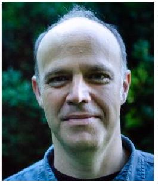

### Slava Krushkal Receives 2019 Simons Fellowship

Slava Krushkal was among the "outstanding mathematicians and theoretical physicists to be awarded Simons Fellowships in 2019." "The Simons Fellows program," the organization’s website explains, "extends academic leaves from one term to a full year, enabling recipients to focus solely on research for the long periods often necessary for significant advances."

Slava plans to use part of the fellowship year as Miller visiting professor at Berkeley, in Spring 2020.

### Sara Maloni Receives CAREER Award by NSF

The National Science Foundation has awarded Assistant Professor Sara Maloni with Early Career Development (CAREER) award. The five-year, $450,000 CAREER award is "the highest distinction that the NSF can provide to junior researchers in the mathematical sciences," according to the organization’s website. This is an honor awarded to only 3 early-career

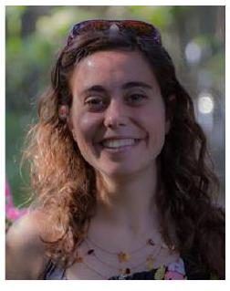

scientists in Topology this year and around 40 scientists in the whole Mathematical Sciences. Sara Maloni works at the intersection of geometry and low-dimensional topology. She studies geometric structures and the way they change when one perturbs the space on which they are constructed.

### Huanchen Bao and Weiqiang Wang Will Receive the 2020 Chevalley Prize

The 2020 Chevalley Prize is awarded to Huanchen Bao and Weiqiang Wang for their fundamental contributions to the theory of quantum symmetric pairs. This award is based on two publications: the paper "Canonical bases arising from quantum symmetric pairs", published in Inventiones Mathematicae, and the monograph "A new approach to Kazhdan-Lusztig theory of type B via quantum symmetric pairs", published in Astérisque. In these works, Huanchen Bao and Weiqiang Wang completely extended the known theory of canonical bases from the case of quantized enveloping algebras to the case of quantum symmetric pairs. Bao and Wang applied their new theory to a longstanding open problem: that of describing the character formulas for the category $\mathcal{O}$ attached to an ortho-symplectic Lie superalgebra of type $\operatorname{osp}(2m+1 \mid 2n)$.

The fact that the theory of canonical bases can be extended to the case of symmetric spaces is entirely unexpected and highly non-trivial. That the new theory has already had dramatic applications to the character theory of Lie superalgebras adds to the significance of the work. Many other applications, for example to a theory of total positivity attached to symmetric spaces, are expected. The two papers of Bao and Wang are the best papers published in Lie theory in recent years and will have an impact on the field for many years to come.

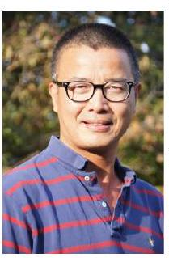

Weiqiang Wang

https://www.ams.org/tools/news?news_id=5611

### Some Recent Developments in Representation Theory

By Weiqiang Wang  
Representation theory is a way of studying groups or algebras by presenting them in terms of matrices or linear operators. For a linear operator acting on a complex vector space, its smallest invariant subspace is $1$-dimensional (spanned by an eigenvector). The smallest vector spaces acted on by a group or an algebra may not be commutative, but they usually are direct sums of finite-dimensional eigenspaces with respect to a finite number of commuting diagonalizable elements in the group/algebra, which can be organized into formal characters; a simple module is then determined by its character. Understanding the simple modules or their characters in some suitable categories is a basic problem in representation theory.

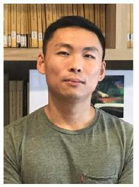

Huanchen Bao

expressed in terms of a canonical basis of Hecke algebra associated to $\mathfrak{g}$.

In search of supersymmetry, one is led to study complex simple Lie superalgebras $\mathfrak{g}$ since the 1970’s. However, developing a super KL theory for Lie superalgebras has been slow going, as the original KL approach breaks down. Brundan (Journal AMS 2003) formulated a KL-type conjecture on the simple characters for type $A$ Lie superalgebra in terms of canonical basis arising from a quantum group $U$. Quantum groups were introduced by Drinfeld (who won a Fields medal for this) and Jimbo independently in 1985, and canonical bases for quantum groups were introduced by Lusztig in 1990. Lusztig has been a leading figure in representation theory since the 1970’s, and he considers canonical bases as one of his top 3 achievements. Brundan’s conjecture has been established by Cheng-Lam-Wang (Duke Math J. 2015).

In his 2015 UVa PhD thesis supervised by Wang, Huanchen Bao solved the longstanding problem of computing simple characters in the BGG category of modules over a simple Lie superalgebra $\mathfrak{g}$ of type $B/C$. (Before this work, there was not even a conjectural solution.) To that end, Bao and Wang developed a theory of canonical bases arising from quantum symmetric pairs, generalizing Lusztig’s construction.

## Department Activities

### The Math Circle

By Slava Krushkal  
The UVa Math Circle is a Fall semester program for talented upper elementary and middle school students. This is the third year of the program, which takes place on weekends on UVa grounds. There are currently 18 students nominated by Charlottesville area schools enrolled in the program - an increase from prior years. The principal instructor is Mathematics professor Slava Krushkal; two Mathematics graduate students, Peter Johnson and Ross Akhmechet, are teaching assistants helping with running the meetings.

The program covers a wide range of topics in combinatorics, number theory, geometry, logic, and algebra, largely independent of the school curriculum.  
The emphasis is on exploring Mathematics and its applications using fun, non-standard problems that students do not usually see at school. For example, some of the recent and upcoming topics discussed in class include the Pigeonhole principle, the Möbius band, rational tangles, magic squares, binary numbers, and the

[figure not shown]

[figure not shown]

Math games are an integral part of the program, giving an engaging way of learning interesting, complex mathematics ideas. For example, the Shannon switching game was invented by Claude Shannon, a pioneer of information theory. Playing this game, students learn about graph theory and in particular the concept of spanning trees. Another game, the game of Hex, introduced by Danish mathematician Piet Hein, and also independently by American mathematician and Nobel prize winner John Nash, is a great way to learn about topological duality in two dimensions. And the Game of Life, designed by the Princeton mathematician John Conway and illustrating the concept of cellular automata, is always a hit with the students.

Each meeting consists of a discussion of homework problems, a Math game, and a focus on a new in-depth topic. Students get lots of practice, both individually and in groups, at solving problems and presenting their solutions.

The Math Circle enables participants to be part of a group of students interested in Math and eager to discuss problems. Providing this environment of students enthusiastic about the subject, which might not be present at school, is one of the main roles of the program.

A common belief, expressed by people who are not research mathematicians, is that "all math formulas are known", and that "there is nothing left to figure out". Students in this program quickly learn that in fact there are fun, interesting, and challenging math problems everywhere! The Math Circle program helps develop the curiosity and skills crucial for the next generation of STEM students.

### Virginia Topology Conference 2018

In December of 2018, the Department hosted the 2018 Virginia Topology Conference, supported by the Institute for Mathematical Sciences at the University of Virginia and by the National Science Foundation. Organized by Slava Krushkal,

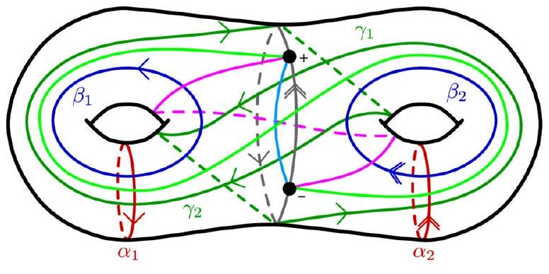

Sara Maloni, and Thomas Mark, the focus was on new methods in the study of smooth topology of $4$-dimensional manifolds, recent developments in the Heegaard Floer theory, gauge theory, and related invariants, and the interactions between these fields.

## Virginia Mathematics Lecture Series

*The Virginia Mathematics Lectures are a Distinguished Lecture Series that IMS established in 2014*

### Spotlight: Andrei Okounkov

By Weiqiang Wang

On October 22–24, 2018, Andrei Okounkov gave a series of 3 lectures entitled "New worlds in Lie theory". He describes the crossroad between enumerative geometry and geometric representation theory of quantum groups developed by him and collaborators (including Maulik and Aganagic). The enumerative geometry concerns about curve counting on a target space, which can be organized under the so-called quantum cohomology/$K$-theory. A good class of the target spaces is Nakajima quiver varieties, which include as the simplest example the cotangent bundle of a Grassmannian of subspaces of fixed dimension in an ambient vector space. A key insight is a geometric

[figure not shown]

construction of the $R$-matrix in quantum groups, leading to the identification between the quantum connection on enumerative geometric side and the Casimir connection on the quantum group side. Consequently, the commutative algebra of quantum multiplications in quantum cohomology/$K$-theory provides a construction of the Bethe algebra in quantum integrable systems, leading to general solutions to several difference equations of interest in general quantum groups.

Andrei Okounkov is currently a professor in mathematics at Columbia University. Before that, he held positions at University of Chicago, UC Berkeley, and Princeton University. He has received many prizes and awards, including a Fields medal in 2006. He was elected to be a member of the US National Academy of Science (2012) and of the American Academy of Arts and Sciences (2016). He was a plenary speaker in International Congress of Mathematicians (ICM) 2018.

### Spotlight: Van Vu

By Yen Do

The first two lectures, "Random matrices: Global distributions" and "Random matrices: Local distributions", took place on April 15th, 2019. In these lectures, Vu described "universality" of the limiting behavior of eigenvalues of random matrices as one of the most central themes in modern random matrix theory, explaining that "universality means the limiting behavior of the eigenvalues does not depend too much on the distribution of the entries of the matrix". Vu presented several important results in the subject in recent times concerning the shape of the limiting spectrum of random matrices. These results could be used to give an approximation for the number of eigenvalues inside a given subset (of the complex plane) for a typical random matrix, even if the subset has a very small measure.

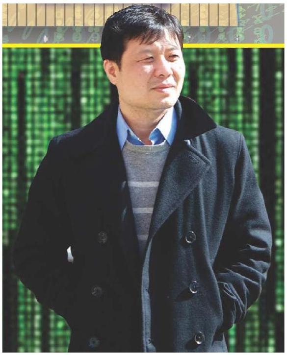

The final lecture, "Random matrices in data science", occurred on the following day, April 16. In this lecture, Vu discussed several interesting applications of random matrix theory in data science. In particular, Vu described the matrix recovery problem, where it can be shown that it is possible to reconstruct a matrix of low rank from its noisy image even if the noise has full rank. A representative example for this problem is the famous Netflix problem about predicting the ratings of each individual for the movies. Vu concluded the lectures with discussions about other possible applications of random matrices, and future research directions.

## Undergraduate Accomplishments

### Distinguished Major Program

In its second year, our revamped Distinguished Major Program is picking up pace. This year two students, Benjamin Keigwin and Yichen Ma, successfully completed the distinguished mathematics major program. This involves completing a research project under the supervision of the faculty member, assembling their findings in a thesis and presenting these at a public defense.

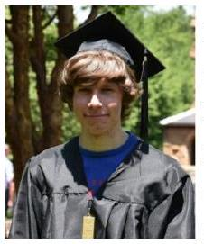

#### Benjamin Keigwin (Adviser: Andrei Rapinchuk)

In his thesis, Ben Keigwin gave an exposition of a number of fundamental results in the theory of elliptic curves. Elliptic curves are ubiquitous in modern number theory and algebraic geometry: they played a crucial role in the proof of Fermat’s Last Theorem and are being actively employed in cryptology. They still hide a lot of secrets - we don’t know, for examples, if the ranks of elliptic curves over the field of rational numbers are bounded. Ben has mastered the results on elliptic curves that open a way to independent research into this and many other open questions in the theory, and has also carried out some numerical experimentation.

Ben is a recipient of the department’s Floyd (2018) and McShane (2019) prizes. Next academic year, Ben will be at the University of Cambridge for their famous Math Tripos, Part III, program, after which he plans to return to the US for graduate studies in mathematics.

#### Yichen Ma (Adviser: Benjamin Hayes)

Yichen Ma wrote a thesis on sofic groups. Roughly speaking, a group is sofic if it can be "approximately modeled" by finite groups. The class of sofic groups is very large: including all

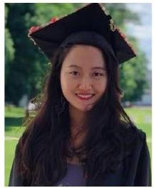

solvable groups, amenable groups, residually finite groups, and linear groups. They are of increasing significance in ergodic theory, geometric group theory, operator algebras, as well as the field of $L^2$-invariants. It is not known if every group is sofic.

Discussing the distinguished major program, Ben said "Yichen did very well in the DMP. She gained mastery of a subject that is of current major research interest. She also learned some very abstract mathematics, such as usage of ultrafilters and ultraproducts, that will be helpful for her career. I am quite pleased with her progress and work ethic, and think she did a fantastic job approaching research level mathematics."

### Gordon E. Keller Mathematics Majors Dinner

**Speaker: Art Roselle**

The 2019 Gordon E. Keller Mathematics Majors Dinner, supported by a generous gift by Doug and Laurel Costa, took place last Spring. In addition to the dinner and awards presentation, attendants enjoyed a talk by Art Roselle, who holds a BA and MA in mathematics from our own department. Mr. Roselle was Jefferson Scholar at UVA and won our E.J. McShane prize in 1992. He is currently a partner at Pamlico Capital, which is an investment firm based in Charlotte, NC, focusing on private companies in healthcare, technology and communications. His talk was entitled "It Was My Understanding There Would Be No Math."

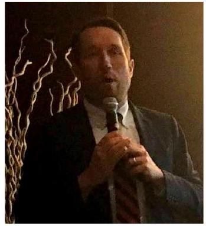

Art Roselle

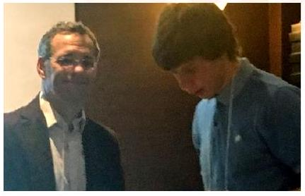

Director of Undergraduate Studies Christian Gromoll with Benjamin Keigwin

### E. J. McShane Prize in Mathematics

*April 2019*

The 2019 E. J. McShane Prize in Mathematics was given to Benjamin Keigwin for his achievements in mathematics.

### Twelve Majors Elected into Phi Beta Kappa

Congratulations to Edward Griffin, Marta Tahantamtai, Alexander Abramenko, Brandon Farris, Sarah Hansen, Brian Seymour, Diego Sierra, Weihua Song, Benjamin Thomas, Abe Trausch, Aaron White, Huaiying Zheng! As the oldest and most distinguished honor society in the country, Phi Beta Kappa offers membership to less than one percent of all undergraduates. Many of the leading figures in American history and culture have begun their careers with election to the society, including seventeen presidents of the United States. As a result, membership is a remarkable accomplishment, both for the student who achieves it and the faculty and staff whose support and guidance has led to this milestone.

### Edwin E. Floyd Prize in Mathematics

*April 2019*

The 2019 Edwin E. Floyd Prize in Mathematics was awarded to Trent Lucas. The prize is awarded to second or third-year students who show exceptional promise in mathematics.

### William Lowell Putnam Mathematical Competition Award

*April 2019*

The 2019 William Lowell Putnam Mathematical Competition Award was given to Emmett Dorlester for his outstanding scores on the exam.

## Undergraduate Activities

### The Putnam Competition

By Juraj Foldes The William Lowell Putnam Mathematical competition is the most famous and one of the hardest mathematical competitions for undergraduate students in USA and Canada. The problems are very difficult and more than half of all participating students achieve zero points (out of 120). The problems are proof based, meaning that a mere answer will usually receive no credit, and a careful mathematical proof is required. The most recent Putnam competition was held on December 1st (the first Saturday in December), and as usual, it consisted of two three-hours long blocks during which students solved two times six problems.

Professor Juraj Foldes organized a semester-long preparatory program that consisted of weekly meetings of interested students with instructors. They discussed solving strategies and techniques often beyond standard undergraduate curriculum. Students were also provided with study materials on competition topics and an abundance of practice problems from previous years and other competitions. There were at least 20 students that showed interest in the competition or training sessions initially, and approximately 5 students attended regularly. For an initial assessment of performance and knowledge, some students participated in the Virginia Tech regional mathematical contest, which is a shorter and easier version of the Putnam competition. There were seven participants from UVA, four of which received nonzero scores. The three highest scoring students were selected for the Putnam team. Four students sat for the Putnam exam at Kerchof Hall, and two of them achieved nonzero scores. The most successful student from UVA was Emmett Dorlester who ranked among best 20% of all participants in USA and Canada, and he received the departmental prize. The second best was Zachary Baugher, who placed among the top third of all students.

### MMATHS Competition

The students of the Undergraduate Math Club at the University of Virginia this year organized MMATHS (Math Majors of America Tournament for High Schools), a competition for high school students from Virginia.

The competition consists of both team and individual rounds. The MATHathon round is a team round where each team works together to solve small packets of problems. The individual round is where each individual tries to solve 12 problems. The top-scoring individuals move to the tiebreaker round, which is proof-based, while the rest of the contestants are randomly placed into new teams for the mixer round, where they work together to solve more problems.

### Undergraduate Research: Contact Geometry

By Thomas Mark Contact geometry is the study of certain geometric structures that first arose in Hamilton’s theory of classical mechanics, and has since been found to have deep and sometimes surprising connections with other areas of physics and pure mathematics. Contact structures arise, for example, in the study of the singularities of certain equations: consider the equation $x^{p}+y^{q}+z^{r}=0$ (where $p$, $q$, and $r$ are fixed positive integers and $x$, $y$, $z$ are complex variables), which has a single singularity at the origin. The intersection of the surface defined by the equation with the unit sphere is then a $3$-dimensional manifold, which carries a natural contact structure determined by the complex structure of the surrounding space. The contact manifolds arising from this family of examples are known as Brieskorn spheres.

In a research project begun in the summer of 2017, undergraduate math major Sebastian Haney studied the contact geometry of Brieskorn spheres from a dynamical point of view. Contact manifolds carry a particular vector field, whose closed integral curves are of particular interest in dynamics; even existence of such closed characteristics is not always clear. However, certain algebraic invariants of contact manifolds can detect these closed orbits, and one such invariant is the "cylindrical contact homology." Haney developed sufficient understanding of the geometry of Brieskorn spheres to make a complete calculation of their cylindrical contact homology, which was previously unknown. In fact, the technical foundations of cylindrical contact homology were established only within the last few years, and Haney’s results are among the first to determine this invariant in concrete cases.

The results of Haney’s work, which was guided by mathematics professor Thomas Mark, are publicly available on the mathematics preprint archive and will be submitted for publication in a research journal. Haney was one of two UVa students to win a prestigious Goldwater scholarship in 2018, and will graduate in May 2020. He is currently applying for graduate programs in mathematics and plans to continue his research in contact geometry while pursuing a Ph.D.

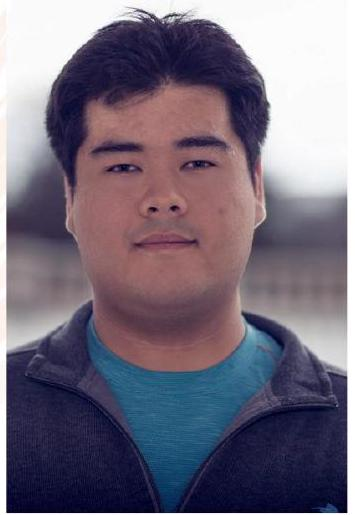

Sebastian Haney

### Sonia Kovalevsky Math Day

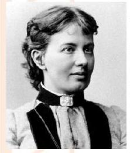

By Sara Maloni

This was the first year that UVA has hosted a Sonia Kovalevsky day, and it was a great success! Middle school students from the Charlottesville area came to Monroe Hall to participate in three activities led by graduate students and faculty in March, and it will

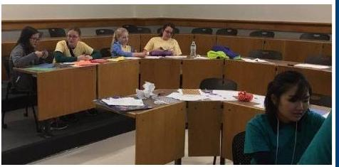

be a great event to carry on in the future. Sonia Days have been held by the AWM at universities for over 20 years, and they provide a way for students to collaborate through hands-on activities that portray math in a different way from what they may be used to in their classrooms.  
"My favorite activity was the tessellation activity, because I’d seen them but never knew how to make one before. I liked learning math in a

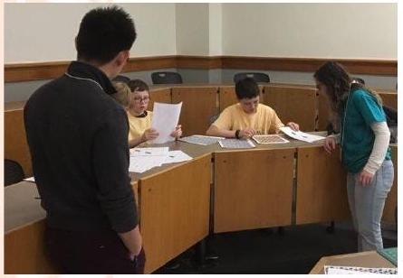

different setting, and it was fun to meet new people," said Kristen Reilley, one of the participants.

Mark Schrecengost, one of the graduate students, says:  
Sonia Day was a lot of fun. I helped with the Mobius strip activity. The students really enjoyed it and had a lot of fun knowing that math wasn’t just writing down addition and

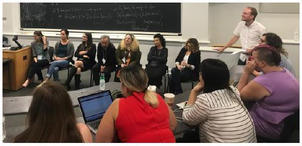

subtraction on a worksheet. I also think it was really cool for the kids to be able to spend the day with each other and us to see that it’s OK to like math. In the Mobius strip activity the students get a small intro to topology. We start by summarizing what topology is, then start constructing surfaces with gluings. Then the students learn how to tell different surfaces apart with properties like "How many sides does something have?" or "What happens when I cut down the middle?" We then give a little discussion on nonorientable surfaces like the Klein bottle or projective plane with gluing constructions as well. I hope we can continue to do it as it is a great community outreach, and also ties in very nicely with the outreach program.

### The Women’s Intellectual Networks Research Symposium (WINRS), “Mid-Atlantic Region: A Meeting of Mathematical Minds”

By Sara Maloni Following the success of a conference organized at Brown University in Spring 2017, we decided to organize a similar event at the University of Virginia in Fall 2018: the "Women’s Intellectual Networks Research Symposium (WINRS), Mid-Atlantic Region: A Meeting of Mathematical Minds" (see http://www.people.virginia.edu/~sm4cw/WINRS.html)

When we started planning the event, we were hoping to gather a group of at least 40 women mathematician from the our region. We had no idea the event would be a complete success with more than 100 people registered with participants from around 30 institutions in Virginia, West Virginia, North and South Carolina, Maryland, DC, Delaware, Pennsylvania and one person also from Ohio.

The conference featured plenary talks, student talks, panels, a poster session, various tutorials and a job/career panel. We wanted to build bridges between universities and connect researchers in similar fields. We believe that this is especially beneficial to upcoming young researchers, women, and underrepresented minorities. The geographic proximity of these universities makes it more likely that networks formed at the conference can be sustained and strengthened, which in turn should increase the probability that these researchers stay in the field and become highly productive members of the community. The chairs of the parallel sessions (Talia Fernos, Rebecca R.G., Constanze Liaw, Lauren Childs, Heather Russell, Della Dumbaugh and Rebecca Fields) did an amazing job recruiting speakers for the Special Sessions spanning most fields of Mathematics. We also had four tutorials:

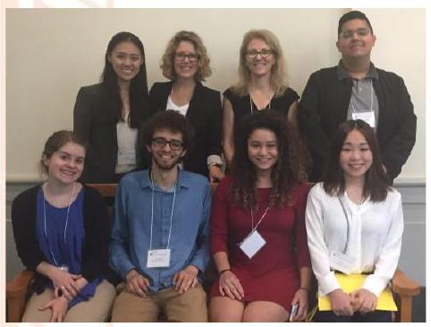

- Elizabeth Denne discussed 3D Printing and illustrating Mathematics
- Axel Saenz (University of Virginia) talked about "Simulations and Computations in Research"
- Jack Love (George Mason University) explained how he organizes "Outreach", and
- Keith Pardue (National Security Agency) discussed "How to prepare for a job interview"

The event ended with a job/career panel chaired by our own Andrew Kobin. The participants asked a lot of questions to the panelists who represented different career paths and who tried to be honest about the pros and cons of their jobs.

We received a lot of positive feedback from the participants and we hope to make this conference an annual get-together event moving from university to university. We already have volunteers who are willing to organize the next one! I also wrote a blog post which will be featured soon in www.womendomath.org with specific advice for people who want to organize such a conference in their own institution. We hope that WINRS will spread everywhere throughout the country.

## Recent PhDs

### James Phillips

Adviser: Andrew Obus

**Reduction and Deformation of One-point Galois Covers** The étale fundamental group of an algebraic curve encodes information about both its finite étale covers and the unramified extensions of its function field. Over an algebraically closed field of characteristic $0$, the Riemann existence theorem provides a powerful tool to compute these fundamental groups. The

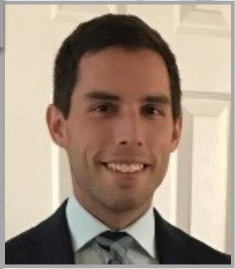

situation is, however, significantly more complicated over fields of positive characteristic $p$. In this thesis, I extend two techniques for studying these fundamental groups. The first relies on the relationship between the fundamental group of a curve and that of its reduction and involves showing that covers of elliptic curves defined over "small" fields branched at exactly one point have good reduction to positive characteristic. This generalizes results of Raynaud and Obus. The second generalizes techniques that Pries used to show the existence of a cover of $\mathbb{P}^{1}$ with a single wildly ramified branch point whose conductor is as small as possible. These techniques include studying degenerations of one-point covers in positive characteristic.

### Brian Thomas

Adviser: Nicholas Kuhn

**Dyer-Lashof operations as extensions and an application to $H_{*}(BU)$**

Algebraic topology is concerned with the algebraic structure associated to topological spaces. There are algebraic operations $Q^{k}$, called Dyer-Lashof operations, that act on the homology of highly structured spaces. We explore a connection between these

[figure not shown]

operations and $\operatorname{Ext}$ groups between unstable modules over the Steenrod algebra. This allows us to make calculations in the stable world, which is often easier. By using a purely algebraic spectral sequence developed by Kuhn and McCarty, along with these $\operatorname{Ext}$ groups, one can obtain information on how the $Q^{k}$ act on $H_{*}\left(\Omega^{\infty} X\right)$ for connective spectra $X$. The $\operatorname{Ext}$ groups are still not easy, but as an application of our method, we show how to calculate the $Q^{k}$ when $X=\Sigma^{2} ku$ which has $H_{*}\left(\Omega^{\infty} X\right)= H_{*}(BU)$, obtaining an action of the Dyer-Lashof algebra that was previously shown by Kochman and Priddy.

### Matthew Gagne

Adviser: Nicholas Kuhn

**The Family Index of the Odd Signature Operator with Coefficients in a Flat Bundle** We study characteristic classes arising as the indices of families of elliptic operators acting on the fibers of an oriented $M$-bundle $f: E \rightarrow B, M$ a smooth oriented closed manifold. Given a family of such operators $D=\left\{D_{b}\right\}_{b \in B}$ one obtains a family index $\operatorname{Ind}(D) \in K^{*}(B)$. If $D$ is "sufficiently natural" (in a sense made precise in [23]) these indices may be viewed as arising from certain universal symbol classes $\sigma \in K^{*}(\operatorname{MTSO}(n))$, where $\operatorname{MTSO}(n)$ is the Thom spectrum of the additive inverse of the universal bundle of oriented $n$-planes over $\operatorname{BSO}(n)$. Explicitly, $\operatorname{Ind}(D)= \alpha_{E}^{*}(\sigma)$ where $\alpha_{E}: \Sigma^{\infty} B_{+} \rightarrow \operatorname{MTSO}(n)$ is the so-called Madsen-Tillman-Weiss map associated to $f: E \rightarrow B$. We show $\operatorname{Ind}\left(D_{V}^{o}\right)=0$ where $D_{V}^{o}$ is the family of odd signature operators on the fibers of $f: E \rightarrow B$ with coefficients in a flat Hermitian vector bundle $V \rightarrow E$. $D_{V}^{o}$ is not universal in the sense of [23] however its index can be described in terms of universal symbols. The vanishing relations implied in cohomology show the higher signatures (Novikov [52]) associated to flat Hermitian bundles provide obstructions to fibering as an odd-dimensional manifold bundle. We end by discussing some examples of flat Hermitian vector bundles to verify that these higher signatures provide a more general obstruction than the usual signature of a $4 k$-dimensional manifold.  
[23] Johannes Ebert. A vanishing theorem for characteristic classes of odd-dimensional manifold bundles. J. Reine Angew. Math., 684:1-29, 2013.  
[52] S. P. Novikov. Algebraic construction and properties of Hermitian analogs of $K$-theory over rings with involution from the viewpoint of Hamiltonian formalism. Applications to differential topology and the theory of characteristic classes. I. II. Izv. Akad. Nauk SSSR Ser. Mat., 34:253-288; ibid. 34 (1970), 475-500, 1970.

### Mariano Echeverria

Adviser: Thomas Mark

**Naturality of the Contact Invariant in Monopole Floer Homology Under Strong Symplectic Cobordisms** The contact invariant is an element in the monopole Floer homology groups of an oriented closed three-manifold canonically associated to a given contact structure. A non-vanishing contact invariant implies that the original contact structure is tight, so understanding its behavior under symplectic cobordisms is of interest if one wants to further exploit this property.

Under a suitable reinterpretation of work by Mrowka and Rollin, we will show that the contact invariant behaves naturally under a strong symplectic cobordism.

As quick applications of the naturality property, we give alternative proofs for the vanishing of the contact invariant in the case of an overtwisted contact structure, its non-vanishing in the case of strongly fillable contact structures and its vanishing in the reduced part of the monopole Floer homology group in the case of a planar contact structure. We also prove that a strong filling of a contact manifold which is an $L$-space must be negative definite.

### Aleksandr Morgan

Adviser: Andrei Rapinchuk

**Bounded Generation of Some Linear Groups** ABSTRACT. Let $R$ be a commutative ring with identity. For $n \geq 2$, we let $\mathrm{E}_{n}(R)$ denote the subgroup of the special linear group $\mathrm{SL}_{n}(R)$ generated by all elementary matrices, and for an ideal $J$ of $R$ we let $\mathrm{E}_{n}(R, J)$ denote the normal subgroup of $\mathrm{E}_{n}(R)$ generated by the elementaries that are congruent to the identity matrix modulo $J$. The goal of this dissertation is to establish several results asserting that in certain situations the groups $\mathrm{E}_{n}(R)$ and $\mathrm{E}_{n}(R, J)$ have finite width with respect to their natural generating sets. In particular, it is shown in Chapter II that if $R$ is a ring of algebraic $S$-integers with infinitely many units, then $\mathrm{E}_{2}(R)$ (which in this case coincides with $\mathrm{SL}_{2}(R)$ ) has width $\leq 9$ with respect to elementary matrices. This result yields bounded generation of $\mathrm{SL}_{2}(R)$ in the case at hand, as an abstract group. The results of Chapter III apply to the ideals $J$ in an arbitrary Noetherian ring $R$ for which the quotient $R / J$ is finite. We show that if $\mathrm{E}_{n}(R)$ has finite width with respect to elementaries, then every element in $\mathrm{E}_{n}\left(R, J^{2}\right)$ is a product of a bounded number of elementary matrices congruent to $I_{n}$ modulo $J$. Assuming further that $R$ satisfies Bass’s stable range condition, we derive from this result that the normal subgroup of $\mathrm{E}_{n}(R)$ generated by a given matrix subject to some conditions, has finite index and finite width with respect to the union of the conjugacy classes of the matrix and its inverse.

### Christopher Leonard

Adviser: Weiqiang Wang

**Categorification of Tensor Products of Representations for Current Algebras and Quantum Groups**

Motivated by the categorified quantum group of Khovanov-Lauda and Rouquier, Webster defined diagrammatic categories whose split Grothendieck groups are isomorphic to tensor products of integrable highest weight modules for the quantum group. Losev and Webster have proposed an axiomatic definition for a tensor product categorification (TPC) of integrable highest weight modules and shown that these TPCs are unique up to a strong form of equivalence.

In this dissertation, we study the categorification of tensor products of different classes of modules. We show that in ADE type, Webster’s category can be regarded as a categorification of a tensor product of Weyl modules for the current algebra by considering the trace decategorification functor.

We also establish a new uniqueness theorem for TPCs of modules over $\mathfrak{sl}_{\mathbb{Z}}$ motivated by work of Brundan, Losev, and Webster. Using this, we lift the super duality equivalence between infinite-rank parabolic BGG categories of general linear Lie (super) algebras of Cheng, Lam, and Wang to a graded equivalence between Koszul graded lifts.

### Gabriel Islambouli

Adviser: Slava Krushkal

**Parallels Between Heegaard Splittings and Trisections of $\mathbf{4}$-Manifolds** For over a century, Heegaard splittings have been recognized as a useful way to describe a $3$-manifold. In 2016, Gay and Kirby [14] introduced a new decomposition of $4$-manifolds called a trisection. They showed that the theory of trisections has many parallels with the theory of Heegaard splittings, including a diagrammatic theory and a stable equivalence theorem.

This dissertation develops the analogies between the theories further in two directions. In one direction, we show that invariants of $3$-manifolds defined using Heegaard splittings can be adapted in order to provide invariants of $4$-manifolds. More precisely, given two smooth, oriented, closed $4$-manifolds, $M_{1}$ and $M_{2}$, we adapt work of Johnson [25] to construct two invariants, $D^{P}\left(M_{1}, M_{2}\right)$ and $D\left(M_{1}, M_{2}\right)$, coming from distances in the pants complex and the dual curve complex, respectively. Our main results are that the invariants are independent of the choices made throughout the process, as well as interpretations of "nearby" manifolds.

In another direction, we show that tools used to distinguish Heegaard splittings of a $3$-manifold can be adapted to distinguish trisections of $4$-manifolds. As a result, we exhibit the first examples of inequivalent trisections. We in fact show that, for every $k \geq 2$, there are infinitely many manifolds admitting $2^{k}-1$ non-diffeomorphic $(3 k, k)$ trisections. Here, the manifolds are spun Seifert fiber spaces and the trisections come from Meier’s spun trisections [34].  
[14] David Gay and Robion Kirby. Trisecting $4$-manifolds. Geom. Topol., 20(6):3097–3132, 2016.  
[25] Jesse Johnson. Heegaard splittings and the pants complex. Algebr. Geom. Topol., 6:853–874, 2006.  
[34] Jeffrey Meier. Trisections and spun $4$-manifolds. ArXiv e-prints, August 2017.

### 2019 Mathematics Department Outstanding Graduate Teaching Assistant Award: Mark Lewers and Mark Schrecengost

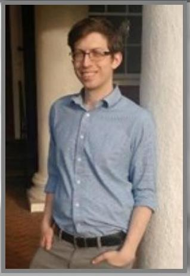

### 2019 All-University Graduate Teaching Award: James Phillips

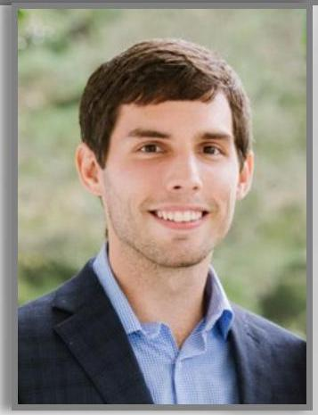